# Reproducible Research Project 1

Andretti

27-AUG-2016

### Analysis of Collected Weekly Activity Data

The purpose of this project is to analyze personal activity data collected from a monitoring device using FitBit. The device collects data at 5 minute intervals on a 24 hour period. The project includes two months of personal activity data collected from a subject in 2012 from November through December.

Three variables are included with the sample dataset.

- steps: Numeric value of the number of steps taking within a 5-minute interval. NA represents Any missing values.
- date: Date when the measurement was taken
- interval: Integer value indicating the 5-minute interval when the measurement was taken.

The dataset of 17,568 observations is stored in a comma-separated-value (CSV) file.

#### Loading and pre-processing the data

1. Load the data
2. Process/transform the data into a tidy dataset

```r
# read data from file
dataset <- read.csv("./data/activity.csv")

# convert date variable to date format
dataset$date <- ymd(dataset$date)
```

#### What is mean total number of steps taken per day?

(Missing values are ignored for this part of the project.)

1. Calculate the total number of steps taken per day

```r
# Group data by date excluding NA values
stepsbyday <- aggregate(steps~date,data=dataset, sum)
```

2. Histogram of the total number of steps taken per day

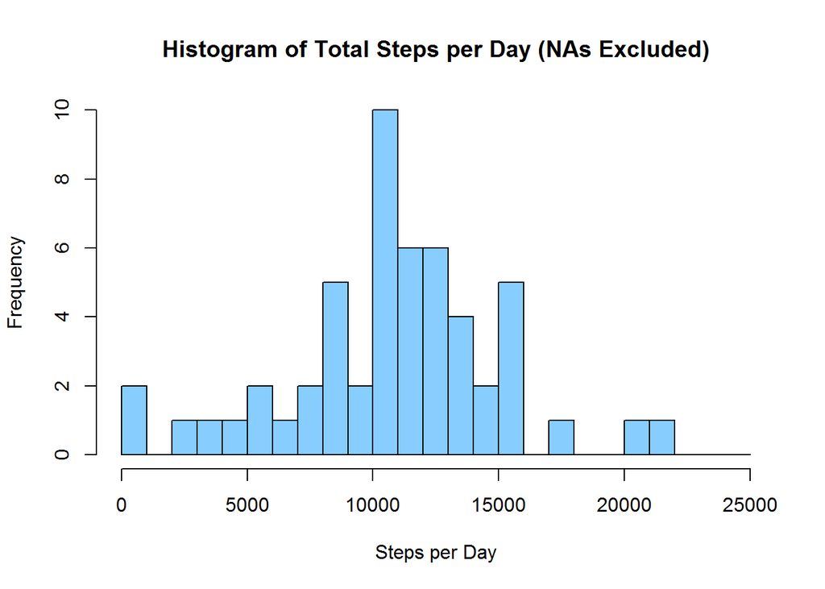

```r
hist(stepsbyday$steps,col="skyblue1", main="Histogram of Total Steps per Day (NAs Excluded)", xlab="Steps per Day", breaks=seq(from=0,to=25000,by=1000))
```

3. Calculate and report the mean and median of the total number of steps taken per day

```r
mean_steps <- format(mean(stepsbyday$steps, na.rm=TRUE), scientific = FALSE)
mean_steps
```

```
## [1] "10766.19"
```

```r
median_steps <- median(stepsbyday$steps, na.rm=TRUE)
median_steps
```

```
## [1] 10765
```

The mean of the total number of steps taken per day: **10766.19**.  
The median of the total number of steps taken per day: **10765**.

#### What is the average daily activity pattern?

1. Time series graph of the 5-minute interval on the x-axis and the average number of steps taken, averaged across all days on the y-axis.

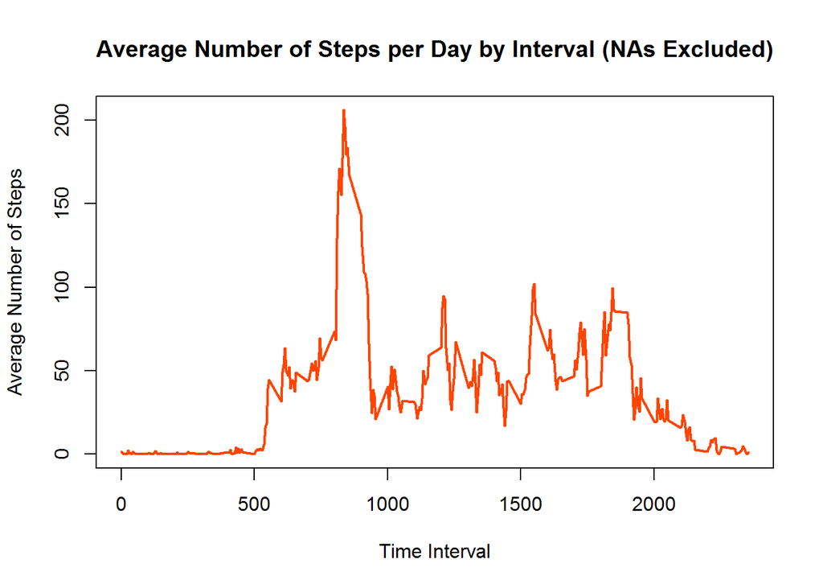

```r
# Steps by interval
interval_steps <- aggregate(steps~interval,data=dataset, mean)

plot(interval_steps$interval,interval_steps$steps,col="orangered",type="l", lwd=2,  main="Average Number of Steps per Day by Interval (NAs Excluded)", xlab="Time Interval", ylab="Average Number of Steps")
```

#### Imputing missing values

**Note** There are a number of days/intervals where there are missing (NA) values

1. Calculate and report the total number of missing values in the dataset

```r
# Total stesps with NA values
missing <- sum(is.na(dataset$steps))
```

Total number of missing (NA values) is **2304**.

2. Create a new dataset as the original with the missing values filled in.

```r
imputed_dataset <-transform(dataset, steps=ifelse(is.na(dataset$steps), interval_steps$steps[match(dataset$interval, interval_steps$interval)], dataset$steps))
```

4. Make a histogram of the total number of steps taken each day. Calculate and report the mean and median of the total number of steps taken per day.

```r
# Total number of steps with imputed values
imputed_totals <- aggregate(steps~date,data=imputed_dataset,sum)

mean_imputed_steps <- format(mean(imputed_totals$steps, na.rm=TRUE), scientific = FALSE)
mean_imputed_steps
```

```
## [1] "10766.19"
```

```r
median_imputed_steps <- format(median(imputed_totals$steps, na.rm=TRUE),scientific = FALSE)
median_imputed_steps
```

```
## [1] "10766.19"
```

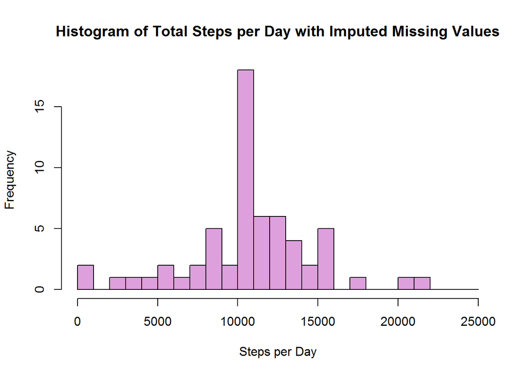

```r
eval=TRUE
hist(imputed_totals$steps,col="plum", main="Histogram of Total Steps per Day with Imputed Missing Values", xlab="Steps per Day", breaks=seq(from=0,to=25000,by=1000))
```

The mean of total number of steps taken per day with imputed values is **10766.19**.  
The median of total number of steps taken per day with imputed values is **10766.19**.

#### Are there differences in activity patterns between weekdays and weekends?

Use the dataset with the imputed values for this part of the project.

1. Create a new factor variable in the dataset with two levels – ‘weekday’ and ‘weekend’ to indicate whether a given dadate is a weekday or a weekend.

```r
# Compare weekday and weekend activity
# Add a new variable with a weekday and a weekend factor
day_activity <- imputed_dataset
day_activity <- mutate(day_activity, daytype=ifelse(weekdays(day_activity$date,abbreviate = F) %in% c('Saturday','Sunday'),"weekend","weekday"))
day_activity$daytype <- as.factor(day_activity[,"daytype"])

meandayactivity <- aggregate(steps~interval+daytype,day_activity,mean)
```

2. Create a time series graph of the 5-minute interval (x-axis) and the average number of steps taken and averaged across all weekday days or weekend days (y-axis.)

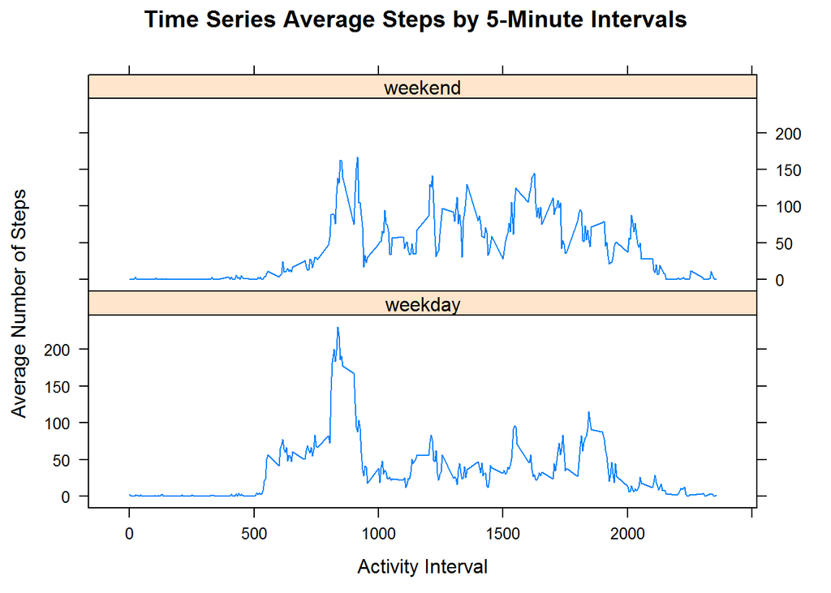

```r
library("lattice")
# 2 panel time series plot of activity on weekdays vs weekends
xyplot(meandayactivity$steps~meandayactivity$interval | meandayactivity$daytype,layout=c(1,2),type="l",xlab="Activity Interval", ylab="Average Number of Steps", main="Time Series Average Steps by 5-Minute Intervals")
```